# Intro_R_Oct8_2021

Tara

10/8/2021

# Welcome

- **Authors**: Tara Henechowicz adapted from plans by Margot Lautens and Luke Johnston
- **Research field**: Neuroscience (Music and Health)
- **Lesson topic**: Intro to R, some data wrangling, statistics, and some visualization
- **Lesson content URL**: https://github.com/UofTCoders/studyGroup/tree/gh-pages/lessons/r/intro

# Why should we use R?

- reproducible science
- wonderful packages to help you for working with your data (even datasets that are very big)!
- packages specific to disciplines: biology, genetics, even neuroimaging
- can customize and create reports with RMarkdown.

# What can we do with R?

- Organize: Tidy data
- Analyze: statistics, machine learning, field-specific techniques
- Visualize

# Starting with R - the command line

## Command Line

The command line executes code like a calculator but does not keep a record of your work. Try entering 2+2 in the commandline, what is the output?

Now lets save 4 as a variable a. The way we do this in R is typing `a <- 4` in the command line. Here the `<-` is acting as an = sign.

In summary, you can execute code in the command line, but you will need to scroll back to see the previous code you executed. To reproduce your code, you will need to create a script.

## Scripts

The type of script we are working in is called and .Rmd file it is an R Markdown script. THis script is helpful for building reports which can later be rendered as a pdf or html file.

Below is a `code chunk`, where you keep a record of your code and you can execute that code. Anything outside of the code can be used as text to supplement your report or write notes about your process. You can open a code chunk using the `Insert` button or using the short cut for your device.

Try running the code chunk below by pressing the green play button.

```r
#this is a comment, this will not run as code.
#Assign the value of 4 to variable "a"
a<-4
#return the value of a
print(a)
```

```
## [1] 4
```

```r
#Ask r if 2+2 is equal to "a"
2+2==a
```

```
## [1] TRUE
```

## Other windows in R

- Environment: all the variables we have saved, our functions, and libraries we have loaded
- History
- Files
- Help

# Starting your script

1. Set our “working directory”, this means we are telling R where to take files from and where to write them.
2. Load in the packages we need to use for our project. If we don’t have the package installed already, you will use the `install.packages` function. Whether you have the package or not, you will load the package using the `library` function.

```r
#Load in the tidyverse, Using R, and dplyr libraries
library(tidyverse)
library(UsingR)
```

3. Load in our data. We will be using a dataset that is already in R, so lets take a look at `babies` and try to store as variable `df` in our environment.

```r
#call the babies dataset
babies
```

```
##        id pluralty outcome date gestation sex  wt parity race age ed ht wt1
## 1      15        5       1 1411       284   1 120      1    8  27  5 62 100
## 2      20        5       1 1499       282   1 113      2    0  33  5 64 135
## 3      58        5       1 1576       279   1 128      1    0  28  2 64 115
## 4      61        5       1 1504       999   1 123      2    0  36  5 69 190
## 5      72        5       1 1425       282   1 108      1    0  23  5 67 125
## 6     100        5       1 1673       286   1 136      4    0  25  2 62  93
## 7     102        5       1 1449       244   1 138      4    7  33  2 62 178
## 8     129        5       1 1562       245   1 132      2    7  23  1 65 140
## 9     142        5       1 1408       289   1 120      3    0  25  4 62 125
## 10    148        5       1 1568       299   1 143      3    0  30  5 66 136
## 11    164        5       1 1554       351   1 140      2    0  27  5 68 120
## 12    171        5       1 1593       282   1 144      4    0  32  2 64 124
## 13    175        5       1 1491       279   1 141      3    0  23  1 63 128
## 14    183        5       1 1446       281   1 110      5    8  36  5 61  99
```

[output cut: 2459 more lines]

```r
#we still need to store this dataset in our R environment
df <- babies
```

Now if we call df, we can see we have the babies dataset

```r
#viewing df
view(df)
#OR
df
```

```
##        id pluralty outcome date gestation sex  wt parity race age ed ht wt1
## 1      15        5       1 1411       284   1 120      1    8  27  5 62 100
## 2      20        5       1 1499       282   1 113      2    0  33  5 64 135
## 3      58        5       1 1576       279   1 128      1    0  28  2 64 115
## 4      61        5       1 1504       999   1 123      2    0  36  5 69 190
## 5      72        5       1 1425       282   1 108      1    0  23  5 67 125
## 6     100        5       1 1673       286   1 136      4    0  25  2 62  93
## 7     102        5       1 1449       244   1 138      4    7  33  2 62 178
## 8     129        5       1 1562       245   1 132      2    7  23  1 65 140
## 9     142        5       1 1408       289   1 120      3    0  25  4 62 125
## 10    148        5       1 1568       299   1 143      3    0  30  5 66 136
## 11    164        5       1 1554       351   1 140      2    0  27  5 68 120
## 12    171        5       1 1593       282   1 144      4    0  32  2 64 124
## 13    175        5       1 1491       279   1 141      3    0  23  1 63 128
## 14    183        5       1 1446       281   1 110      5    8  36  5 61  99
```

[output cut: 2459 more lines]

Lets use the function write.csv to take that data and save it as a .csv file in our current directory

```r
write.csv(babies, "babies.csv")
```

A few ways to lad data are to: - manually use the import dataset button in Rstudio (and copy the code from the output) - use `read_csv()` function from readr package

```r
#copy the code generated by the import dataset button
library(readr)
babies2 <- read_csv("babies.csv")
View(babies)
```

# Viewing the data and its structure

1. Instead of viewing the whole dataset we can use the `head` function to view the first 6 rows of the data.
2. If you want to view more rows of data, use the argument n= to change the size of the table returned.

```r
#view the whole dataset
view(df)
#use the head function to view the first 6 rows of the data
head(df)
```

```
##    id pluralty outcome date gestation sex  wt parity race age ed ht wt1 drace
## 1  15        5       1 1411       284   1 120      1    8  27  5 62 100     8
## 2  20        5       1 1499       282   1 113      2    0  33  5 64 135     0
## 3  58        5       1 1576       279   1 128      1    0  28  2 64 115     5
## 4  61        5       1 1504       999   1 123      2    0  36  5 69 190     3
## 5  72        5       1 1425       282   1 108      1    0  23  5 67 125     0
## 6 100        5       1 1673       286   1 136      4    0  25  2 62  93     3
##   dage ded dht dwt marital inc smoke time number
## 1   31   5  65 110       1   1     0    0      0
## 2   38   5  70 148       1   4     0    0      0
## 3   32   1  99 999       1   2     1    1      1
## 4   43   4  68 197       1   8     3    5      5
## 5   24   5  99 999       1   1     1    1      5
## 6   28   2  64 130       1   4     2    2      2
```

```r
#Look at the first 10 rows of the data
head(df, n=10)
```

```
##     id pluralty outcome date gestation sex  wt parity race age ed ht wt1 drace
## 1   15        5       1 1411       284   1 120      1    8  27  5 62 100     8
## 2   20        5       1 1499       282   1 113      2    0  33  5 64 135     0
## 3   58        5       1 1576       279   1 128      1    0  28  2 64 115     5
## 4   61        5       1 1504       999   1 123      2    0  36  5 69 190     3
## 5   72        5       1 1425       282   1 108      1    0  23  5 67 125     0
## 6  100        5       1 1673       286   1 136      4    0  25  2 62  93     3
## 7  102        5       1 1449       244   1 138      4    7  33  2 62 178     7
## 8  129        5       1 1562       245   1 132      2    7  23  1 65 140     7
## 9  142        5       1 1408       289   1 120      3    0  25  4 62 125     3
## 10 148        5       1 1568       299   1 143      3    0  30  5 66 136     0
##    dage ded dht dwt marital inc smoke time number
## 1    31   5  65 110       1   1     0    0      0
## 2    38   5  70 148       1   4     0    0      0
## 3    32   1  99 999       1   2     1    1      1
## 4    43   4  68 197       1   8     3    5      5
## 5    24   5  99 999       1   1     1    1      5
## 6    28   2  64 130       1   4     2    2      2
## 7    37   4  99 999       1  98     0    0      0
## 8    23   4  71 192       1   2     0    0      0
## 9    26   1  70 180       0   2     0    0      0
## 10   34   5  99 999       1   2     1    1      4
```

3. Another important function is `str` it returns the structure of the object. For a `data.frame` that we have here, it will also give you the column names and the structure of those columns. `dim` is also a useful function that will retrun the dimesnions of your data.frame. `names()` shows the column names. `glimpse()` is a `dplyr` only function that ressembles `str` but unlike `str` it allows you to see all your columns. `row.names()` or `rownames()` will return a vector of the rownames of the dataset. However, only `rownames()`can be changed, we will return to the uses of this function later.

```r
#use the str() function on df
str(df)
```

```
## 'data.frame':    1236 obs. of  23 variables:
##  $ id       : num  15 20 58 61 72 100 102 129 142 148 ...
##  $ pluralty : num  5 5 5 5 5 5 5 5 5 5 ...
##  $ outcome  : num  1 1 1 1 1 1 1 1 1 1 ...
##  $ date     : num  1411 1499 1576 1504 1425 ...
##  $ gestation: num  284 282 279 999 282 286 244 245 289 299 ...
##  $ sex      : num  1 1 1 1 1 1 1 1 1 1 ...
##  $ wt       : num  120 113 128 123 108 136 138 132 120 143 ...
##  $ parity   : num  1 2 1 2 1 4 4 2 3 3 ...
##  $ race     : num  8 0 0 0 0 0 7 7 0 0 ...
##  $ age      : num  27 33 28 36 23 25 33 23 25 30 ...
##  $ ed       : num  5 5 2 5 5 2 2 1 4 5 ...
##  $ ht       : num  62 64 64 69 67 62 62 65 62 66 ...
##  $ wt1      : num  100 135 115 190 125 93 178 140 125 136 ...
##  $ drace    : num  8 0 5 3 0 3 7 7 3 0 ...
##  $ dage     : num  31 38 32 43 24 28 37 23 26 34 ...
##  $ ded      : num  5 5 1 4 5 2 4 4 1 5 ...
##  $ dht      : num  65 70 99 68 99 64 99 71 70 99 ...
##  $ dwt      : num  110 148 999 197 999 130 999 192 180 999 ...
##  $ marital  : num  1 1 1 1 1 1 1 1 0 1 ...
##  $ inc      : num  1 4 2 8 1 4 98 2 2 2 ...
##  $ smoke    : num  0 0 1 3 1 2 0 0 0 1 ...
##  $ time     : num  0 0 1 5 1 2 0 0 0 1 ...
##  $ number   : num  0 0 1 5 5 2 0 0 0 4 ...
```

```r
#use the dim() function to return the size of df
dim(df)
```

```
## [1] 1236   23
```

```r
#use names() to return the column names
names(df)
```

```
##  [1] "id"        "pluralty"  "outcome"   "date"      "gestation" "sex"
##  [7] "wt"        "parity"    "race"      "age"       "ed"        "ht"
## [13] "wt1"       "drace"     "dage"      "ded"       "dht"       "dwt"
## [19] "marital"   "inc"       "smoke"     "time"      "number"
```

```r
#use row.names() or rownames() to return a vector of the rownames
row.names(df)
```

```
##    [1] "1"    "2"    "3"    "4"    "5"    "6"    "7"    "8"    "9"    "10"
##   [11] "11"   "12"   "13"   "14"   "15"   "16"   "17"   "18"   "19"   "20"
##   [21] "21"   "22"   "23"   "24"   "25"   "26"   "27"   "28"   "29"   "30"
##   [31] "31"   "32"   "33"   "34"   "35"   "36"   "37"   "38"   "39"   "40"
##   [41] "41"   "42"   "43"   "44"   "45"   "46"   "47"   "48"   "49"   "50"
##   [51] "51"   "52"   "53"   "54"   "55"   "56"   "57"   "58"   "59"   "60"
##   [61] "61"   "62"   "63"   "64"   "65"   "66"   "67"   "68"   "69"   "70"
##   [71] "71"   "72"   "73"   "74"   "75"   "76"   "77"   "78"   "79"   "80"
##   [81] "81"   "82"   "83"   "84"   "85"   "86"   "87"   "88"   "89"   "90"
##   [91] "91"   "92"   "93"   "94"   "95"   "96"   "97"   "98"   "99"   "100"
##  [101] "101"  "102"  "103"  "104"  "105"  "106"  "107"  "108"  "109"  "110"
##  [111] "111"  "112"  "113"  "114"  "115"  "116"  "117"  "118"  "119"  "120"
##  [121] "121"  "122"  "123"  "124"  "125"  "126"  "127"  "128"  "129"  "130"
##  [131] "131"  "132"  "133"  "134"  "135"  "136"  "137"  "138"  "139"  "140"
##  [141] "141"  "142"  "143"  "144"  "145"  "146"  "147"  "148"  "149"  "150"
```

[output cut: 109 more lines]

# Summary statistics and exploring patterns

1. `summary()` shows a quick description of the summary statistics (means, median, frequency)for each of your columns.

This function is especially useful for finding issues in the data coding and in the data structure. For example, look at the variable sex - is there is something strange here? Are there any other variables that might have issues? These are all issues we can fix when we tidy the data, we will return to data tidying in the next section.

```r
#give a summary of df
summary(df)
```

```
##        id          pluralty    outcome       date        gestation
##  Min.   :  15   Min.   :5   Min.   :1   Min.   :1350   Min.   :148.0
##  1st Qu.:5286   1st Qu.:5   1st Qu.:1   1st Qu.:1444   1st Qu.:272.0
##  Median :6730   Median :5   Median :1   Median :1540   Median :280.0
##  Mean   :6001   Mean   :5   Mean   :1   Mean   :1536   Mean   :286.9
##  3rd Qu.:7583   3rd Qu.:5   3rd Qu.:1   3rd Qu.:1627   3rd Qu.:288.0
##  Max.   :9263   Max.   :5   Max.   :1   Max.   :1714   Max.   :999.0
##       sex          wt            parity            race             age
##  Min.   :1   Min.   : 55.0   Min.   : 0.000   Min.   : 0.000   Min.   :15.00
##  1st Qu.:1   1st Qu.:108.8   1st Qu.: 0.000   1st Qu.: 0.000   1st Qu.:23.00
##  Median :1   Median :120.0   Median : 1.000   Median : 3.000   Median :26.00
##  Mean   :1   Mean   :119.6   Mean   : 1.932   Mean   : 3.206   Mean   :27.37
##  3rd Qu.:1   3rd Qu.:131.0   3rd Qu.: 3.000   3rd Qu.: 7.000   3rd Qu.:31.00
##  Max.   :1   Max.   :176.0   Max.   :13.000   Max.   :99.000   Max.   :99.00
##        ed              ht             wt1          drace             dage
##  Min.   :0.000   Min.   :53.00   Min.   : 87   Min.   : 0.000   Min.   :18.00
##  1st Qu.:2.000   1st Qu.:62.00   1st Qu.:115   1st Qu.: 0.000   1st Qu.:25.00
##  Median :2.000   Median :64.00   Median :126   Median : 3.000   Median :29.00
##  Mean   :2.922   Mean   :64.67   Mean   :154   Mean   : 3.665   Mean   :30.74
##  3rd Qu.:4.000   3rd Qu.:66.00   3rd Qu.:140   3rd Qu.: 7.000   3rd Qu.:35.00
##  Max.   :9.000   Max.   :99.00   Max.   :999   Max.   :99.000   Max.   :99.00
##       ded             dht             dwt           marital
##  Min.   :0.000   Min.   :60.00   Min.   :110.0   Min.   :0.000
##  1st Qu.:2.000   1st Qu.:70.00   1st Qu.:165.0   1st Qu.:1.000
##  Median :4.000   Median :73.00   Median :190.0   Median :1.000
##  Mean   :3.189   Mean   :81.67   Mean   :505.4   Mean   :1.038
##  3rd Qu.:5.000   3rd Qu.:99.00   3rd Qu.:999.0   3rd Qu.:1.000
##  Max.   :9.000   Max.   :99.00   Max.   :999.0   Max.   :5.000
##       inc            smoke             time            number
##  Min.   : 0.00   Min.   :0.0000   Min.   : 0.000   Min.   : 0.000
##  1st Qu.: 2.00   1st Qu.:0.0000   1st Qu.: 0.000   1st Qu.: 0.000
##  Median : 4.00   Median :1.0000   Median : 1.000   Median : 1.000
##  Mean   :13.16   Mean   :0.8681   Mean   : 1.748   Mean   : 2.604
##  3rd Qu.: 7.00   3rd Qu.:1.0000   3rd Qu.: 1.000   3rd Qu.: 3.000
##  Max.   :98.00   Max.   :9.0000   Max.   :99.000   Max.   :98.000
```

2. Plotting to explore the data

Before we plot any of the columns, we need to know how to select columns from the dataset. To call a column of the data we can use the $ operator: df$sex will give us the sex column. With dataframes, we can call specific rows and collumns using the index. For example with df[1,6], will give us the 1st row and the 6th column. We can also select a range of columns or rows using `:` operator.

```r
#Try calling the wt column using the `$`
df$wt
```

```
##    [1] 120 113 128 123 108 136 138 132 120 143 140 144 141 110 114 115  92 115
##   [19] 144 119 105 115 137 122 131 103 146 114 125 114 122  93 130 119 113 134
##   [37] 107 134 122 128 129 110 138 111  87 143 155 110 122 145 115 108 102 143
##   [55] 146 124 124 145 106  75 107 124 122 101 128 104  97 137 103 142 130 156
##   [73] 133 120  91 127 153 121 120  99 149 129 139 114 138 129 138 131 125 114
##   [91] 128 134 114  92  85 135  87 125 128 105 120 119 116 107 119 133 155 126
##  [109] 129 137 103 125  91 134  95 118 141 131 121 100 131 118 152 121 117 115
##  [127] 112  94 109 132 117 101 112 128 128 117 134 127  93 122 100 147 120 144
##  [145] 105 136 102 160 113 126 126 115 127 119 129 123 118 133 105 134 144 111
##  [163] 125 135 134 116 129 113 131 126 121 121 138 136 120 122 134 101 112 132
##  [181] 136 113  96 124 113 131 137 133 107  96 142 136  75 125 104 130  90 118
##  [199] 123 137 101 142  98 124 151 109 150 119 131 101 113 127  97 117 150  85
##  [217] 128 105  90 115 107 121 119 117 134 117 115 110 130 140 111  93 154 125
##  [235]  93 122 129 126  85 173 144 114 111 154 150 111 126 122 141 142  99 113
##  [253] 149 117 130 106 128 125 114 130 116  81 124 125 110 125 138 142 115 102
```

[output cut: 54 more lines]

```r
#Try another way to get the wt column
df[,7]
```

```
##    [1] 120 113 128 123 108 136 138 132 120 143 140 144 141 110 114 115  92 115
##   [19] 144 119 105 115 137 122 131 103 146 114 125 114 122  93 130 119 113 134
##   [37] 107 134 122 128 129 110 138 111  87 143 155 110 122 145 115 108 102 143
##   [55] 146 124 124 145 106  75 107 124 122 101 128 104  97 137 103 142 130 156
##   [73] 133 120  91 127 153 121 120  99 149 129 139 114 138 129 138 131 125 114
##   [91] 128 134 114  92  85 135  87 125 128 105 120 119 116 107 119 133 155 126
##  [109] 129 137 103 125  91 134  95 118 141 131 121 100 131 118 152 121 117 115
##  [127] 112  94 109 132 117 101 112 128 128 117 134 127  93 122 100 147 120 144
##  [145] 105 136 102 160 113 126 126 115 127 119 129 123 118 133 105 134 144 111
##  [163] 125 135 134 116 129 113 131 126 121 121 138 136 120 122 134 101 112 132
##  [181] 136 113  96 124 113 131 137 133 107  96 142 136  75 125 104 130  90 118
##  [199] 123 137 101 142  98 124 151 109 150 119 131 101 113 127  97 117 150  85
##  [217] 128 105  90 115 107 121 119 117 134 117 115 110 130 140 111  93 154 125
##  [235]  93 122 129 126  85 173 144 114 111 154 150 111 126 122 141 142  99 113
##  [253] 149 117 130 106 128 125 114 130 116  81 124 125 110 125 138 142 115 102
```

[output cut: 54 more lines]

```r
#Try to get the first ten rows of the weight column
df[1:10,7]
```

```
##  [1] 120 113 128 123 108 136 138 132 120 143
```

2. There are some base functions that allow us to visualize our data: `hist()` will provide a historgram of a variable. `plot()` can allow you to compare two variables, x and y, in many different types of plots.

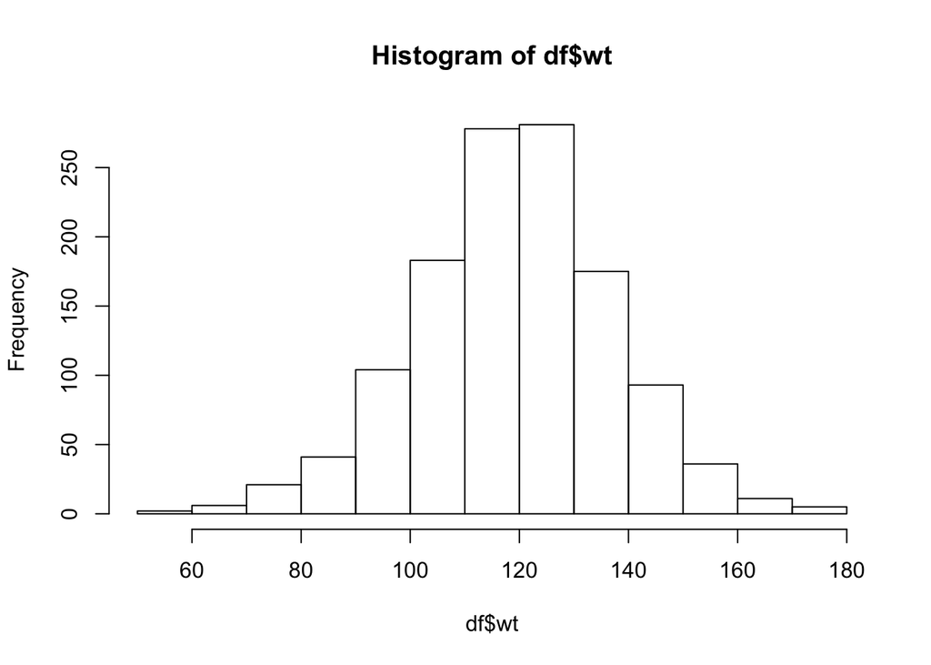

```r
#Try plotting wt as a histogram
hist(df$wt)
```

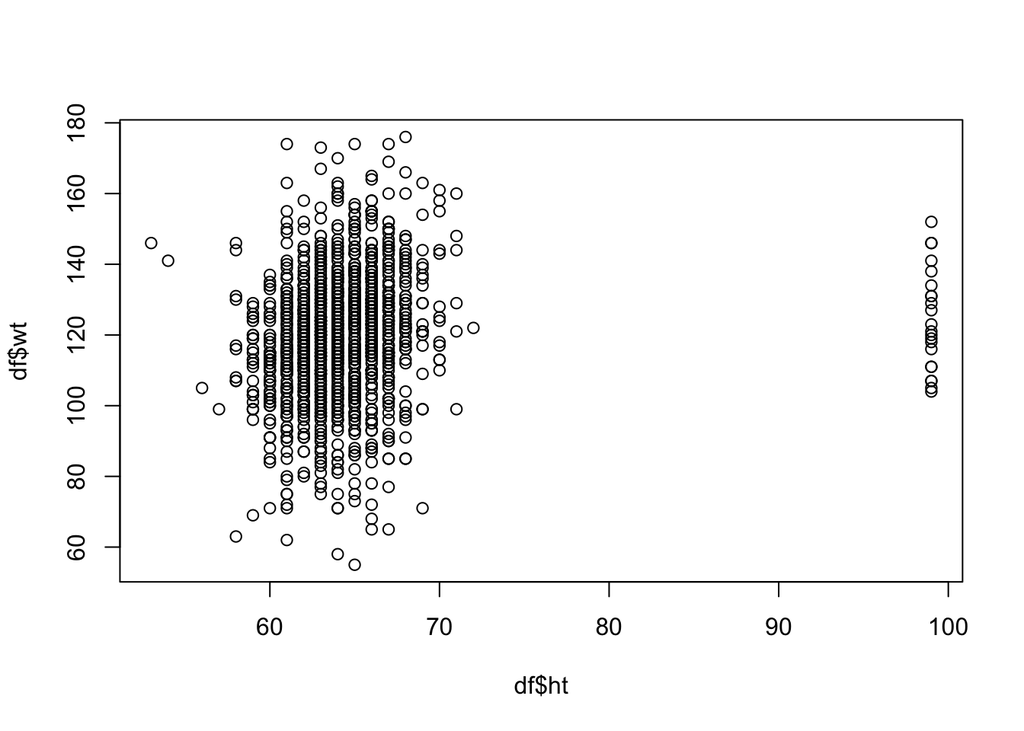

```r
#try plotting ht as the x variable and wt as the y variable
plot(x=df$ht, y=df$wt)
```

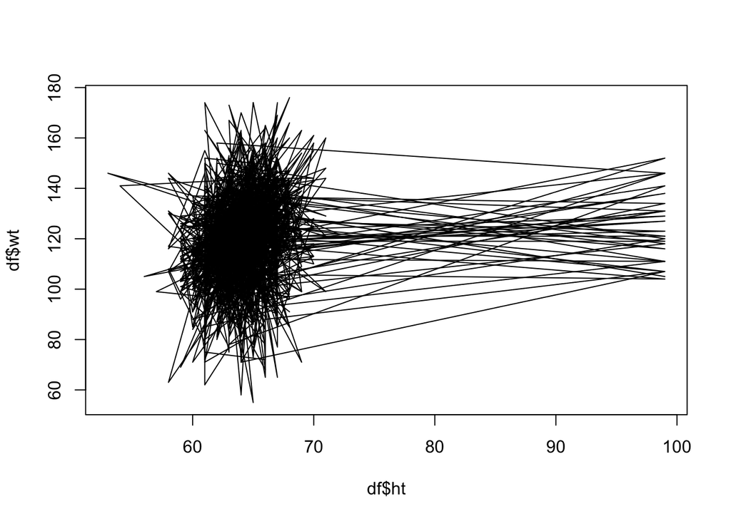

```r
#Now lets use the help function ? to view the plot function
?plot
#Lets try changing the type argument
plot(x=df$ht, y=df$wt, type = "l")
```

# Introduction to data tidying and tidyverse

1. When we looked at the `summary()` of our data, we found that some variables were coded as numeric, when they should be binary or categorical (factors). `as.logical()` will transform the variable into a logical `TRUE` or `FALSE` `as.numeric()` will transform the variable into a numeric variable `as.character()` will transform the variable into character strings `as.factor()` will transform the variable into a factor. However, the levels will be created automatically and might not be the correct order. You might want to use `factor()` to change the variable.

```r
#lets take a look at the summary again
summary(df)
```

```
##        id          pluralty    outcome       date        gestation
##  Min.   :  15   Min.   :5   Min.   :1   Min.   :1350   Min.   :148.0
##  1st Qu.:5286   1st Qu.:5   1st Qu.:1   1st Qu.:1444   1st Qu.:272.0
##  Median :6730   Median :5   Median :1   Median :1540   Median :280.0
##  Mean   :6001   Mean   :5   Mean   :1   Mean   :1536   Mean   :286.9
##  3rd Qu.:7583   3rd Qu.:5   3rd Qu.:1   3rd Qu.:1627   3rd Qu.:288.0
##  Max.   :9263   Max.   :5   Max.   :1   Max.   :1714   Max.   :999.0
##       sex          wt            parity            race             age
##  Min.   :1   Min.   : 55.0   Min.   : 0.000   Min.   : 0.000   Min.   :15.00
##  1st Qu.:1   1st Qu.:108.8   1st Qu.: 0.000   1st Qu.: 0.000   1st Qu.:23.00
##  Median :1   Median :120.0   Median : 1.000   Median : 3.000   Median :26.00
##  Mean   :1   Mean   :119.6   Mean   : 1.932   Mean   : 3.206   Mean   :27.37
##  3rd Qu.:1   3rd Qu.:131.0   3rd Qu.: 3.000   3rd Qu.: 7.000   3rd Qu.:31.00
##  Max.   :1   Max.   :176.0   Max.   :13.000   Max.   :99.000   Max.   :99.00
##        ed              ht             wt1          drace             dage
##  Min.   :0.000   Min.   :53.00   Min.   : 87   Min.   : 0.000   Min.   :18.00
##  1st Qu.:2.000   1st Qu.:62.00   1st Qu.:115   1st Qu.: 0.000   1st Qu.:25.00
##  Median :2.000   Median :64.00   Median :126   Median : 3.000   Median :29.00
##  Mean   :2.922   Mean   :64.67   Mean   :154   Mean   : 3.665   Mean   :30.74
##  3rd Qu.:4.000   3rd Qu.:66.00   3rd Qu.:140   3rd Qu.: 7.000   3rd Qu.:35.00
##  Max.   :9.000   Max.   :99.00   Max.   :999   Max.   :99.000   Max.   :99.00
##       ded             dht             dwt           marital
##  Min.   :0.000   Min.   :60.00   Min.   :110.0   Min.   :0.000
##  1st Qu.:2.000   1st Qu.:70.00   1st Qu.:165.0   1st Qu.:1.000
##  Median :4.000   Median :73.00   Median :190.0   Median :1.000
##  Mean   :3.189   Mean   :81.67   Mean   :505.4   Mean   :1.038
##  3rd Qu.:5.000   3rd Qu.:99.00   3rd Qu.:999.0   3rd Qu.:1.000
##  Max.   :9.000   Max.   :99.00   Max.   :999.0   Max.   :5.000
##       inc            smoke             time            number
##  Min.   : 0.00   Min.   :0.0000   Min.   : 0.000   Min.   : 0.000
##  1st Qu.: 2.00   1st Qu.:0.0000   1st Qu.: 0.000   1st Qu.: 0.000
##  Median : 4.00   Median :1.0000   Median : 1.000   Median : 1.000
##  Mean   :13.16   Mean   :0.8681   Mean   : 1.748   Mean   : 2.604
##  3rd Qu.: 7.00   3rd Qu.:1.0000   3rd Qu.: 1.000   3rd Qu.: 3.000
##  Max.   :98.00   Max.   :9.0000   Max.   :99.000   Max.   :98.000
```

```r
#let's look at what the coding should be for the variables in babies by looking at the data key
?babies
#Sex is a factor with 3 levels, 1,2,9
as.factor(df$sex)
```

```
##    [1] 1 1 1 1 1 1 1 1 1 1 1 1 1 1 1 1 1 1 1 1 1 1 1 1 1 1 1 1 1 1 1 1 1 1 1 1 1
##   [38] 1 1 1 1 1 1 1 1 1 1 1 1 1 1 1 1 1 1 1 1 1 1 1 1 1 1 1 1 1 1 1 1 1 1 1 1 1
##   [75] 1 1 1 1 1 1 1 1 1 1 1 1 1 1 1 1 1 1 1 1 1 1 1 1 1 1 1 1 1 1 1 1 1 1 1 1 1
##  [112] 1 1 1 1 1 1 1 1 1 1 1 1 1 1 1 1 1 1 1 1 1 1 1 1 1 1 1 1 1 1 1 1 1 1 1 1 1
##  [149] 1 1 1 1 1 1 1 1 1 1 1 1 1 1 1 1 1 1 1 1 1 1 1 1 1 1 1 1 1 1 1 1 1 1 1 1 1
##  [186] 1 1 1 1 1 1 1 1 1 1 1 1 1 1 1 1 1 1 1 1 1 1 1 1 1 1 1 1 1 1 1 1 1 1 1 1 1
##  [223] 1 1 1 1 1 1 1 1 1 1 1 1 1 1 1 1 1 1 1 1 1 1 1 1 1 1 1 1 1 1 1 1 1 1 1 1 1
##  [260] 1 1 1 1 1 1 1 1 1 1 1 1 1 1 1 1 1 1 1 1 1 1 1 1 1 1 1 1 1 1 1 1 1 1 1 1 1
##  [297] 1 1 1 1 1 1 1 1 1 1 1 1 1 1 1 1 1 1 1 1 1 1 1 1 1 1 1 1 1 1 1 1 1 1 1 1 1
##  [334] 1 1 1 1 1 1 1 1 1 1 1 1 1 1 1 1 1 1 1 1 1 1 1 1 1 1 1 1 1 1 1 1 1 1 1 1 1
##  [371] 1 1 1 1 1 1 1 1 1 1 1 1 1 1 1 1 1 1 1 1 1 1 1 1 1 1 1 1 1 1 1 1 1 1 1 1 1
##  [408] 1 1 1 1 1 1 1 1 1 1 1 1 1 1 1 1 1 1 1 1 1 1 1 1 1 1 1 1 1 1 1 1 1 1 1 1 1
##  [445] 1 1 1 1 1 1 1 1 1 1 1 1 1 1 1 1 1 1 1 1 1 1 1 1 1 1 1 1 1 1 1 1 1 1 1 1 1
##  [482] 1 1 1 1 1 1 1 1 1 1 1 1 1 1 1 1 1 1 1 1 1 1 1 1 1 1 1 1 1 1 1 1 1 1 1 1 1
##  [519] 1 1 1 1 1 1 1 1 1 1 1 1 1 1 1 1 1 1 1 1 1 1 1 1 1 1 1 1 1 1 1 1 1 1 1 1 1
```

[output cut: 20 more lines]

```r
#only one level is showing, let's use factor() to and set levels = c("1","0")
factor(df$sex, levels = c("1", "2", "9"))
```

```
##    [1] 1 1 1 1 1 1 1 1 1 1 1 1 1 1 1 1 1 1 1 1 1 1 1 1 1 1 1 1 1 1 1 1 1 1 1 1 1
##   [38] 1 1 1 1 1 1 1 1 1 1 1 1 1 1 1 1 1 1 1 1 1 1 1 1 1 1 1 1 1 1 1 1 1 1 1 1 1
##   [75] 1 1 1 1 1 1 1 1 1 1 1 1 1 1 1 1 1 1 1 1 1 1 1 1 1 1 1 1 1 1 1 1 1 1 1 1 1
##  [112] 1 1 1 1 1 1 1 1 1 1 1 1 1 1 1 1 1 1 1 1 1 1 1 1 1 1 1 1 1 1 1 1 1 1 1 1 1
##  [149] 1 1 1 1 1 1 1 1 1 1 1 1 1 1 1 1 1 1 1 1 1 1 1 1 1 1 1 1 1 1 1 1 1 1 1 1 1
##  [186] 1 1 1 1 1 1 1 1 1 1 1 1 1 1 1 1 1 1 1 1 1 1 1 1 1 1 1 1 1 1 1 1 1 1 1 1 1
##  [223] 1 1 1 1 1 1 1 1 1 1 1 1 1 1 1 1 1 1 1 1 1 1 1 1 1 1 1 1 1 1 1 1 1 1 1 1 1
##  [260] 1 1 1 1 1 1 1 1 1 1 1 1 1 1 1 1 1 1 1 1 1 1 1 1 1 1 1 1 1 1 1 1 1 1 1 1 1
##  [297] 1 1 1 1 1 1 1 1 1 1 1 1 1 1 1 1 1 1 1 1 1 1 1 1 1 1 1 1 1 1 1 1 1 1 1 1 1
##  [334] 1 1 1 1 1 1 1 1 1 1 1 1 1 1 1 1 1 1 1 1 1 1 1 1 1 1 1 1 1 1 1 1 1 1 1 1 1
##  [371] 1 1 1 1 1 1 1 1 1 1 1 1 1 1 1 1 1 1 1 1 1 1 1 1 1 1 1 1 1 1 1 1 1 1 1 1 1
##  [408] 1 1 1 1 1 1 1 1 1 1 1 1 1 1 1 1 1 1 1 1 1 1 1 1 1 1 1 1 1 1 1 1 1 1 1 1 1
##  [445] 1 1 1 1 1 1 1 1 1 1 1 1 1 1 1 1 1 1 1 1 1 1 1 1 1 1 1 1 1 1 1 1 1 1 1 1 1
##  [482] 1 1 1 1 1 1 1 1 1 1 1 1 1 1 1 1 1 1 1 1 1 1 1 1 1 1 1 1 1 1 1 1 1 1 1 1 1
##  [519] 1 1 1 1 1 1 1 1 1 1 1 1 1 1 1 1 1 1 1 1 1 1 1 1 1 1 1 1 1 1 1 1 1 1 1 1 1
```

[output cut: 20 more lines]

```r
#now we have to save our new variable
df$sex <- factor(df$sex, levels = c("1", "2", "9"))
```

Try it yourself: 1. check the data key on the babies data set using ?babies and look at the variable marital 2. change the variable marital to a character 3. look at the summary of marital as a character variable 4. now change marital to a factor 5. look at the summary of marital as a factor, what is the difference between the summary if marital is a character or a factor?

2. There are many helpful functions to deal with missing data in R. You might want to check how many missing values there are using `is.na()` or remove missing all rows of data using `na.omit()`.

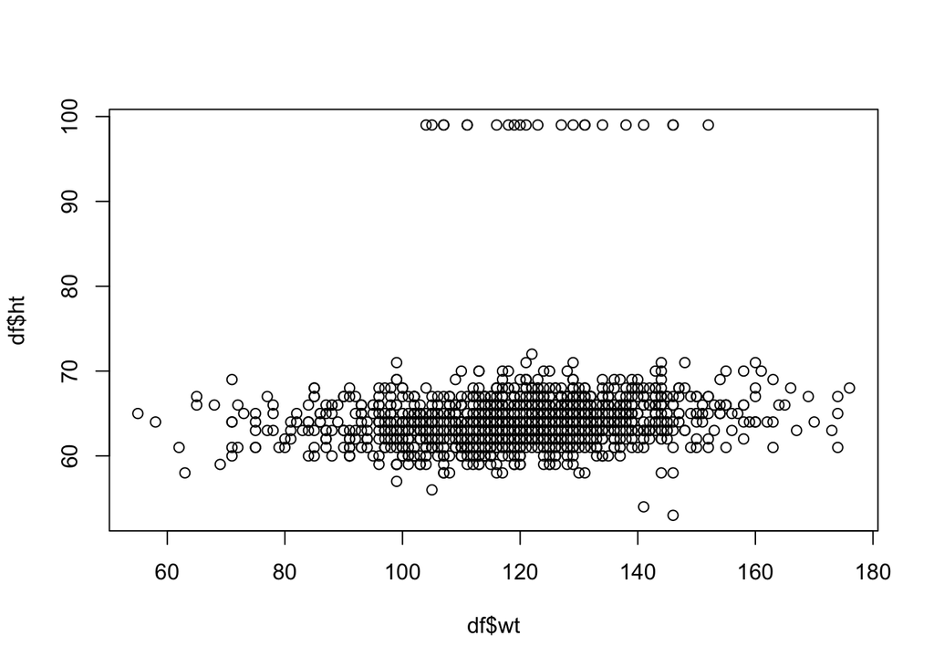

```r
plot(df$wt, df$ht)
```

For this dataset, in the ht column, NAs are coded as 99. We want to create a statement telling R that if df$ht is equal to 99, we want to rewrite that code as NA, if that is not TRUE, then keep the original output. This is called an ifelse statement. An easy way to do this in R is using the `ifelse()` function. The first value is the statement of what we are looking for, `df$ht==99`, the next value will be what we should do if that statement is`TRUE`, the third value will be what to do if the statement is`FALSE`. Once we have the 99s coded as NA, we can count the number of NAs in the vector using`is.na()`. Lastly, we can remove rows that have NAs using`na.omit()`.

```r
#Use the ifelse() function to tell R to replace df$ht values that are 99 with NA.
ifelse(df$ht == 99, NA, df$ht)
```

```
##    [1] 62 64 64 69 67 62 62 65 62 66 68 64 63 61 63 63 65 60 68 66 56 67 66 68
##   [25] 65 65 58 65 65 66 61 61 66 60 65 67 63 63 65 65 61 63 NA 61 65 63 66 60
##   [49] 66 63 62 65 61 64 67 60 70 65 60 61 61 67 65 63 63 65 63 69 63 63 66 63
##   [73] 66 62 60 62 63 63 63 62 65 64 68 67 66 71 65 63 70 67 59 62 60 67 61 64
##   [97] 61 62 62 64 60 64 61 65 61 66 66 65 64 65 65 65 67 65 66 64 66 67 66 65
##  [121] 61 66 67 69 69 61 65 62 66 67 62 67 64 60 66 64 69 65 65 65 62 65 65 63
##  [145] 61 66 63 71 68 66 68 61 NA 66 NA 64 68 60 61 60 67 62 66 63 63 65 69 67
##  [169] 65 59 62 68 65 61 66 72 66 65 62 64 62 65 64 63 62 NA 63 61 58 59 66 63
##  [193] 63 61 65 63 63 66 66 61 63 64 63 63 65 61 61 68 65 63 62 62 61 64 65 67
##  [217] 70 61 67 65 62 63 64 64 68 65 66 63 62 63 NA 66 65 64 66 63 63 63 68 63
##  [241] 65 65 63 65 67 62 66 65 68 63 59 63 61 65 64 65 64 64 66 63 66 64 62 65
##  [265] 66 63 64 66 60 67 61 63 66 62 67 65 65 66 65 67 66 59 62 63 68 66 64 71
##  [289] 65 63 67 64 68 71 63 60 59 60 61 64 62 64 61 65 66 64 66 65 62 60 68 66
##  [313] 66 62 62 63 67 65 67 66 66 67 66 64 66 63 60 62 67 64 63 65 64 67 64 62
##  [337] 64 NA 59 63 67 68 65 61 67 65 63 64 66 59 65 63 63 63 67 64 62 64 62 63
```

[output cut: 37 more lines]

```r
#Store the new variable back into df$ht
df$ht <- ifelse(df$ht == 99, NA, df$ht)
#To count the number of NAs
summary(is.na(df$ht))
```

```
##    Mode   FALSE    TRUE
## logical    1214      22
```

```r
#To remove the rows that have NA in them from the dataset, we can use the na.omit() function
na.omit(df)
```

```
##        id pluralty outcome date gestation sex  wt parity race age ed ht wt1
## 1      15        5       1 1411       284   1 120      1    8  27  5 62 100
## 2      20        5       1 1499       282   1 113      2    0  33  5 64 135
## 3      58        5       1 1576       279   1 128      1    0  28  2 64 115
## 4      61        5       1 1504       999   1 123      2    0  36  5 69 190
## 5      72        5       1 1425       282   1 108      1    0  23  5 67 125
## 6     100        5       1 1673       286   1 136      4    0  25  2 62  93
## 7     102        5       1 1449       244   1 138      4    7  33  2 62 178
## 8     129        5       1 1562       245   1 132      2    7  23  1 65 140
## 9     142        5       1 1408       289   1 120      3    0  25  4 62 125
## 10    148        5       1 1568       299   1 143      3    0  30  5 66 136
## 11    164        5       1 1554       351   1 140      2    0  27  5 68 120
## 12    171        5       1 1593       282   1 144      4    0  32  2 64 124
## 13    175        5       1 1491       279   1 141      3    0  23  1 63 128
## 14    183        5       1 1446       281   1 110      5    8  36  5 61  99
```

[output cut: 2415 more lines]

```r
#Let's store the  df with NAs omited into a new data frame, name it df2
df2 <- na.omit(df)
```

# Introduction to Tidyverse

Data wrangling is a bit tedious in base R. There are two great packages which we loaded in at the beginning of the session, `dplyr`and `tidyverse`.

`select` is a `dplyr` function that lets us select columns from the dataset.

Columns can be selected individually with `,`, in a series with `:` or removed with `-`.

```r
library(dplyr)
#The first two  lines of code are the same.
dplyr::select(df,id,pluralty,outcome,date)
```

```
##        id pluralty outcome date
## 1      15        5       1 1411
## 2      20        5       1 1499
## 3      58        5       1 1576
## 4      61        5       1 1504
## 5      72        5       1 1425
## 6     100        5       1 1673
## 7     102        5       1 1449
## 8     129        5       1 1562
## 9     142        5       1 1408
## 10    148        5       1 1568
## 11    164        5       1 1554
## 12    171        5       1 1593
## 13    175        5       1 1491
## 14    183        5       1 1446
```

[output cut: 1222 more lines]

```r
dplyr::select(df, id:date)
```

```
##        id pluralty outcome date
## 1      15        5       1 1411
## 2      20        5       1 1499
## 3      58        5       1 1576
## 4      61        5       1 1504
## 5      72        5       1 1425
## 6     100        5       1 1673
## 7     102        5       1 1449
## 8     129        5       1 1562
## 9     142        5       1 1408
## 10    148        5       1 1568
## 11    164        5       1 1554
## 12    171        5       1 1593
## 13    175        5       1 1491
## 14    183        5       1 1446
```

[output cut: 1222 more lines]

```r
#This line of code selects all columns except ht and wt.
dplyr::select(df,-ht, -wt)
```

```
##        id pluralty outcome date gestation sex parity race age ed wt1 drace dage
## 1      15        5       1 1411       284   1      1    8  27  5 100     8   31
## 2      20        5       1 1499       282   1      2    0  33  5 135     0   38
## 3      58        5       1 1576       279   1      1    0  28  2 115     5   32
## 4      61        5       1 1504       999   1      2    0  36  5 190     3   43
## 5      72        5       1 1425       282   1      1    0  23  5 125     0   24
## 6     100        5       1 1673       286   1      4    0  25  2  93     3   28
## 7     102        5       1 1449       244   1      4    7  33  2 178     7   37
## 8     129        5       1 1562       245   1      2    7  23  1 140     7   23
## 9     142        5       1 1408       289   1      3    0  25  4 125     3   26
## 10    148        5       1 1568       299   1      3    0  30  5 136     0   34
## 11    164        5       1 1554       351   1      2    0  27  5 120     5   28
## 12    171        5       1 1593       282   1      4    0  32  2 124     0   36
## 13    175        5       1 1491       279   1      3    0  23  1 128     5   28
## 14    183        5       1 1446       281   1      5    8  36  5  99     0   32
```

[output cut: 2459 more lines]

`dplyr` also comes with a `%>%` pipe function (via the `magrittr` package), which works similar to how the Bash shell `|` pipe works. The command on the right-hand side takes the output from the command on the left-hand side, just like how a plumbing pipe works for water. The `.` object represents the output from the pipe, but it doesn’t have to be used as using `%>%` implies also using `.`.

```r
#The outputs of each of these two lines of code are the same.
df %>%
  dplyr::select(id,pluralty,outcome,date)
```

```
##        id pluralty outcome date
## 1      15        5       1 1411
## 2      20        5       1 1499
## 3      58        5       1 1576
## 4      61        5       1 1504
## 5      72        5       1 1425
## 6     100        5       1 1673
## 7     102        5       1 1449
## 8     129        5       1 1562
## 9     142        5       1 1408
## 10    148        5       1 1568
## 11    164        5       1 1554
## 12    171        5       1 1593
## 13    175        5       1 1491
## 14    183        5       1 1446
```

[output cut: 1222 more lines]

```r
df %>%
  dplyr::select(id:date)
```

```
##        id pluralty outcome date
## 1      15        5       1 1411
## 2      20        5       1 1499
## 3      58        5       1 1576
## 4      61        5       1 1504
## 5      72        5       1 1425
## 6     100        5       1 1673
## 7     102        5       1 1449
## 8     129        5       1 1562
## 9     142        5       1 1408
## 10    148        5       1 1568
## 11    164        5       1 1554
## 12    171        5       1 1593
## 13    175        5       1 1491
## 14    183        5       1 1446
```

[output cut: 1222 more lines]

```r
#This line of code selects all columns except ht and wt.
df %>%
  dplyr::select(-ht, -wt)
```

```
##        id pluralty outcome date gestation sex parity race age ed wt1 drace dage
## 1      15        5       1 1411       284   1      1    8  27  5 100     8   31
## 2      20        5       1 1499       282   1      2    0  33  5 135     0   38
## 3      58        5       1 1576       279   1      1    0  28  2 115     5   32
## 4      61        5       1 1504       999   1      2    0  36  5 190     3   43
## 5      72        5       1 1425       282   1      1    0  23  5 125     0   24
## 6     100        5       1 1673       286   1      4    0  25  2  93     3   28
## 7     102        5       1 1449       244   1      4    7  33  2 178     7   37
## 8     129        5       1 1562       245   1      2    7  23  1 140     7   23
## 9     142        5       1 1408       289   1      3    0  25  4 125     3   26
## 10    148        5       1 1568       299   1      3    0  30  5 136     0   34
## 11    164        5       1 1554       351   1      2    0  27  5 120     5   28
## 12    171        5       1 1593       282   1      4    0  32  2 124     0   36
## 13    175        5       1 1491       279   1      3    0  23  1 128     5   28
## 14    183        5       1 1446       281   1      5    8  36  5  99     0   32
```

[output cut: 2459 more lines]

You can rename columns either using `rename` or `select` (the new name is on the left hand side, so `newname = oldname`). However, with the `select` command, only that column gets selected, while `rename` selects all columns.

```r
df %>% rename(weight = wt)
```

```
##        id pluralty outcome date gestation sex weight parity race age ed ht wt1
## 1      15        5       1 1411       284   1    120      1    8  27  5 62 100
## 2      20        5       1 1499       282   1    113      2    0  33  5 64 135
## 3      58        5       1 1576       279   1    128      1    0  28  2 64 115
## 4      61        5       1 1504       999   1    123      2    0  36  5 69 190
## 5      72        5       1 1425       282   1    108      1    0  23  5 67 125
## 6     100        5       1 1673       286   1    136      4    0  25  2 62  93
## 7     102        5       1 1449       244   1    138      4    7  33  2 62 178
## 8     129        5       1 1562       245   1    132      2    7  23  1 65 140
## 9     142        5       1 1408       289   1    120      3    0  25  4 62 125
## 10    148        5       1 1568       299   1    143      3    0  30  5 66 136
## 11    164        5       1 1554       351   1    140      2    0  27  5 68 120
## 12    171        5       1 1593       282   1    144      4    0  32  2 64 124
## 13    175        5       1 1491       279   1    141      3    0  23  1 63 128
## 14    183        5       1 1446       281   1    110      5    8  36  5 61  99
```

[output cut: 2459 more lines]

```r
df %>% dplyr::select(weight = wt)
```

```
##      weight
## 1       120
## 2       113
## 3       128
## 4       123
## 5       108
## 6       136
## 7       138
## 8       132
## 9       120
## 10      143
## 11      140
## 12      144
## 13      141
## 14      110
```

[output cut: 1222 more lines]

```r
#find the babies that have a weight that equal to 100 grams
filter(df,wt==100)
```

```
##        id pluralty outcome date gestation sex  wt parity race age ed ht wt1
## 120  1878        5       1 1698       243   1 100      1    0  39  2 65 170
## 141  2274        5       1 1375       265   1 100      6    0  39  2 62 107
## 315  5447        5       1 1357       277   1 100      2    0  31  2 62 100
## 383  5945        5       1 1376       249   1 100      3    7  24  4 67 100
## 443  6172        5       1 1387       275   1 100      4    0  27  4 64 111
## 473  6268        5       1 1419       275   1 100      0    0  25  2 64 125
## 677  6901        5       1 1510       275   1 100      3    7  26  2 60 115
## 701  6982        5       1 1550       295   1 100      0    0  21  2 68 125
## 819  7310        5       1 1612       288   1 100      0    0  28  1 61 108
## 849  7383        5       1 1604       264   1 100      2    7  29  2 64 120
## 879  7462        5       1 1553       272   1 100      2    7  30  4 64 150
## 1000 7765        5       1 1637       270   1 100      0    7  21  4 65 132
## 1087 8026        5       1 1680       264   1 100      3    5  28  2 60 111
## 1098 8051        5       1 1683       281   1 100      2    8  24  2 61 115
```

[output cut: 21 more lines]

```r
#find the babies that have a weight that are greater than 100 grams
df %>% filter(wt>100)
```

```
##        id pluralty outcome date gestation sex  wt parity race age ed ht wt1
## 1      15        5       1 1411       284   1 120      1    8  27  5 62 100
## 2      20        5       1 1499       282   1 113      2    0  33  5 64 135
## 3      58        5       1 1576       279   1 128      1    0  28  2 64 115
## 4      61        5       1 1504       999   1 123      2    0  36  5 69 190
## 5      72        5       1 1425       282   1 108      1    0  23  5 67 125
## 6     100        5       1 1673       286   1 136      4    0  25  2 62  93
## 7     102        5       1 1449       244   1 138      4    7  33  2 62 178
## 8     129        5       1 1562       245   1 132      2    7  23  1 65 140
## 9     142        5       1 1408       289   1 120      3    0  25  4 62 125
## 10    148        5       1 1568       299   1 143      3    0  30  5 66 136
## 11    164        5       1 1554       351   1 140      2    0  27  5 68 120
## 12    171        5       1 1593       282   1 144      4    0  32  2 64 124
## 13    175        5       1 1491       279   1 141      3    0  23  1 63 128
## 14    183        5       1 1446       281   1 110      5    8  36  5 61  99
```

[output cut: 2111 more lines]

```r
#filter for marital status does not equal 1
df %>% filter(marital!=1)
```

```
##        id pluralty outcome date gestation sex  wt parity race age ed ht wt1
## 9     142        5       1 1408       289   1 120      3    0  25  4 62 125
## 145  2355        5       1 1415       268   1 105      5    0  32  4 61 115
## 184  2908        5       1 1613       277   1 124      3    7  29  2 63 220
## 261  4604        5       1 1598       148   1 116      7    7  28  1 66 135
## 298  5234        5       1 1609       273   1  85      5    5  26  1 60 105
## 306  5269        5       1 1362       285   1 110      0    7  19  2 64 130
## 419  6057        5       1 1392       290   1 123      2    0  28  4 66 107
## 482  6296        5       1 1445       291   1 124      3    7  26  1 66 999
## 507  6360        5       1 1420       272   1  98      0    7  35  4 64 129
## 558  6540        5       1 1511       264   1 105      5    7  30  4 65 105
## 568  6565        5       1 1470       269   1 115      4    5  41  2 63 165
## 569  6569        5       1 1393       254   1 127      1    0  27  2 67 146
## 709  6992        5       1 1410       288   1 117      0    8  28  5 63 140
## 717  7008        5       1 1538       279   1 103      0    7  22  5 65 145
```

[output cut: 43 more lines]

```r
## These are all the same:
df %>% filter(wt>100)  %>% filter(marital!=1)
```

```
##        id pluralty outcome date gestation sex  wt parity race age ed ht wt1
## 9     142        5       1 1408       289   1 120      3    0  25  4 62 125
## 145  2355        5       1 1415       268   1 105      5    0  32  4 61 115
## 184  2908        5       1 1613       277   1 124      3    7  29  2 63 220
## 261  4604        5       1 1598       148   1 116      7    7  28  1 66 135
## 306  5269        5       1 1362       285   1 110      0    7  19  2 64 130
## 419  6057        5       1 1392       290   1 123      2    0  28  4 66 107
## 482  6296        5       1 1445       291   1 124      3    7  26  1 66 999
## 558  6540        5       1 1511       264   1 105      5    7  30  4 65 105
## 568  6565        5       1 1470       269   1 115      4    5  41  2 63 165
## 569  6569        5       1 1393       254   1 127      1    0  27  2 67 146
## 709  6992        5       1 1410       288   1 117      0    8  28  5 63 140
## 717  7008        5       1 1538       279   1 103      0    7  22  5 65 145
## 806  7261        5       1 1593       277   1 113      3    5  38  5 64 108
## 877  7457        5       1 1612       306   1 122      0    7  22  4 62 100
```

[output cut: 33 more lines]

```r
df %>% filter(wt>100 , marital!=1)
```

```
##        id pluralty outcome date gestation sex  wt parity race age ed ht wt1
## 9     142        5       1 1408       289   1 120      3    0  25  4 62 125
## 145  2355        5       1 1415       268   1 105      5    0  32  4 61 115
## 184  2908        5       1 1613       277   1 124      3    7  29  2 63 220
## 261  4604        5       1 1598       148   1 116      7    7  28  1 66 135
## 306  5269        5       1 1362       285   1 110      0    7  19  2 64 130
## 419  6057        5       1 1392       290   1 123      2    0  28  4 66 107
## 482  6296        5       1 1445       291   1 124      3    7  26  1 66 999
## 558  6540        5       1 1511       264   1 105      5    7  30  4 65 105
## 568  6565        5       1 1470       269   1 115      4    5  41  2 63 165
## 569  6569        5       1 1393       254   1 127      1    0  27  2 67 146
## 709  6992        5       1 1410       288   1 117      0    8  28  5 63 140
## 717  7008        5       1 1538       279   1 103      0    7  22  5 65 145
## 806  7261        5       1 1593       277   1 113      3    5  38  5 64 108
## 877  7457        5       1 1612       306   1 122      0    7  22  4 62 100
```

[output cut: 33 more lines]

```r
df %>% filter(wt>100 & marital!=1)
```

```
##        id pluralty outcome date gestation sex  wt parity race age ed ht wt1
## 9     142        5       1 1408       289   1 120      3    0  25  4 62 125
## 145  2355        5       1 1415       268   1 105      5    0  32  4 61 115
## 184  2908        5       1 1613       277   1 124      3    7  29  2 63 220
## 261  4604        5       1 1598       148   1 116      7    7  28  1 66 135
## 306  5269        5       1 1362       285   1 110      0    7  19  2 64 130
## 419  6057        5       1 1392       290   1 123      2    0  28  4 66 107
## 482  6296        5       1 1445       291   1 124      3    7  26  1 66 999
## 558  6540        5       1 1511       264   1 105      5    7  30  4 65 105
## 568  6565        5       1 1470       269   1 115      4    5  41  2 63 165
## 569  6569        5       1 1393       254   1 127      1    0  27  2 67 146
## 709  6992        5       1 1410       288   1 117      0    8  28  5 63 140
## 717  7008        5       1 1538       279   1 103      0    7  22  5 65 145
## 806  7261        5       1 1593       277   1 113      3    5  38  5 64 108
## 877  7457        5       1 1612       306   1 122      0    7  22  4 62 100
```

[output cut: 33 more lines]

We can start chaining these commands together using the `%>%` command. There is no limit to how long a chain can be. `mutate` creates a new column.

```r
df %>%
  filter(wt>100) %>%
  mutate(hwratio = wt/ht) %>%
  dplyr::select(-ht, -wt)
```

```
##        id pluralty outcome date gestation sex parity race age ed wt1 drace dage
## 1      15        5       1 1411       284   1      1    8  27  5 100     8   31
## 2      20        5       1 1499       282   1      2    0  33  5 135     0   38
## 3      58        5       1 1576       279   1      1    0  28  2 115     5   32
## 4      61        5       1 1504       999   1      2    0  36  5 190     3   43
## 5      72        5       1 1425       282   1      1    0  23  5 125     0   24
## 6     100        5       1 1673       286   1      4    0  25  2  93     3   28
## 7     102        5       1 1449       244   1      4    7  33  2 178     7   37
## 8     129        5       1 1562       245   1      2    7  23  1 140     7   23
## 9     142        5       1 1408       289   1      3    0  25  4 125     3   26
## 10    148        5       1 1568       299   1      3    0  30  5 136     0   34
## 11    164        5       1 1554       351   1      2    0  27  5 120     5   28
## 12    171        5       1 1593       282   1      4    0  32  2 124     0   36
## 13    175        5       1 1491       279   1      3    0  23  1 128     5   28
## 14    183        5       1 1446       281   1      5    8  36  5  99     0   32
```

[output cut: 2111 more lines]

R is very powerful at analyzing data but is biased. To get your data into a nicer and more analyable format, you can use the `tidyverse` package.  
See what `gather` does in the code below. Then see what `spread` does.

```r
## Compare this:
df
```

```
##        id pluralty outcome date gestation sex  wt parity race age ed ht wt1
## 1      15        5       1 1411       284   1 120      1    8  27  5 62 100
## 2      20        5       1 1499       282   1 113      2    0  33  5 64 135
## 3      58        5       1 1576       279   1 128      1    0  28  2 64 115
## 4      61        5       1 1504       999   1 123      2    0  36  5 69 190
## 5      72        5       1 1425       282   1 108      1    0  23  5 67 125
## 6     100        5       1 1673       286   1 136      4    0  25  2 62  93
## 7     102        5       1 1449       244   1 138      4    7  33  2 62 178
## 8     129        5       1 1562       245   1 132      2    7  23  1 65 140
## 9     142        5       1 1408       289   1 120      3    0  25  4 62 125
## 10    148        5       1 1568       299   1 143      3    0  30  5 66 136
## 11    164        5       1 1554       351   1 140      2    0  27  5 68 120
## 12    171        5       1 1593       282   1 144      4    0  32  2 64 124
## 13    175        5       1 1491       279   1 141      3    0  23  1 63 128
## 14    183        5       1 1446       281   1 110      5    8  36  5 61  99
```

[output cut: 2459 more lines]

```r
## With this:
df %>%
  gather(ht,wt, key ="variable", value = "grams")
```

```
##        id pluralty outcome date gestation sex parity race age ed wt1 drace dage
## 1      15        5       1 1411       284   1      1    8  27  5 100     8   31
## 2      20        5       1 1499       282   1      2    0  33  5 135     0   38
## 3      58        5       1 1576       279   1      1    0  28  2 115     5   32
## 4      61        5       1 1504       999   1      2    0  36  5 190     3   43
## 5      72        5       1 1425       282   1      1    0  23  5 125     0   24
## 6     100        5       1 1673       286   1      4    0  25  2  93     3   28
## 7     102        5       1 1449       244   1      4    7  33  2 178     7   37
## 8     129        5       1 1562       245   1      2    7  23  1 140     7   23
## 9     142        5       1 1408       289   1      3    0  25  4 125     3   26
## 10    148        5       1 1568       299   1      3    0  30  5 136     0   34
## 11    164        5       1 1554       351   1      2    0  27  5 120     5   28
## 12    171        5       1 1593       282   1      4    0  32  2 124     0   36
## 13    175        5       1 1491       279   1      3    0  23  1 128     5   28
## 14    183        5       1 1446       281   1      5    8  36  5  99     0   32
```

[output cut: 4931 more lines]

```r
## And back again:
df %>%
  gather(ht,wt, key ="variable", value = "grams") %>%
  spread(variable, grams)
```

```
##        id pluralty outcome date gestation sex parity race age ed wt1 drace dage
## 1      15        5       1 1411       284   1      1    8  27  5 100     8   31
## 2      20        5       1 1499       282   1      2    0  33  5 135     0   38
## 3      58        5       1 1576       279   1      1    0  28  2 115     5   32
## 4      61        5       1 1504       999   1      2    0  36  5 190     3   43
## 5      72        5       1 1425       282   1      1    0  23  5 125     0   24
## 6     100        5       1 1673       286   1      4    0  25  2  93     3   28
## 7     102        5       1 1449       244   1      4    7  33  2 178     7   37
## 8     129        5       1 1562       245   1      2    7  23  1 140     7   23
## 9     142        5       1 1408       289   1      3    0  25  4 125     3   26
## 10    148        5       1 1568       299   1      3    0  30  5 136     0   34
## 11    164        5       1 1554       351   1      2    0  27  5 120     5   28
## 12    171        5       1 1593       282   1      4    0  32  2 124     0   36
## 13    175        5       1 1491       279   1      3    0  23  1 128     5   28
## 14    183        5       1 1446       281   1      5    8  36  5  99     0   32
```

[output cut: 2459 more lines]

Combined with `dplyr`’s `group_by` and `summarise` you can quickly summarise data or do further, more complicated analyses. `group_by` makes it so further analyses or operations work on the groups. `summarise` transforms the data to only contain the new variable(s) created, in this case the mean. You can try out `max()`,`min()`,`median()` and `sd()`.

```r
df %>%
  group_by(smoke) %>% #group by smoking status
  summarise(mean = mean(wt)) #summarize the mean
```

```
## # A tibble: 5 × 2
##   smoke  mean
##   <dbl> <dbl>
## 1     0  123.
## 2     1  114.
## 3     2  123.
## 4     3  124.
## 5     9  127.
```